# Case Study

Nathan M

2024-01-26

## Business task

The purpose of this analysis is to identify ways that consumers use smart devices. What are some trends in usage, how could they apply to customers, and how could that affect marketing.

## Data sources

This analysis used a publicly available dataset on Kaggle, “[FitBit Fitness Tracker Data](https://www.kaggle.com/datasets/arashnic/fitbit).” It includes several overlapping CSV files, of varying sizes, from a few KB with 67 observations of 8 variables, to 85 MB with 2.5 million observations of 3 variables. Some are for specific activities from the devices, and others are combined, using both long and wide data formats.

```r
dailyActivity <- read_csv("data/dailyActivity_merged.csv")
dailyCalories <- read_csv("data/dailyCalories_merged.csv")
dailyIntensities <- read_csv("data/dailyIntensities_merged.csv")
dailySteps <- read_csv("data/dailySteps_merged.csv")
```

## Data cleaning

Exploratory data analysis revealed some tables were in a wide format, with time and distance observations by multiple categories in one row. They had to be transformed into an intermediary long data form, separating the categories from time or distance values, turning the categories into factors, then finally transformed into a wider format with each categorical variable with its associated time and/or distance. Some categories also used different names between their time and distance values.

All the dates in this dataset were strings, which had to be transformed into actual date variables.

```r
dailyActivity <- dailyActivity %>%
  mutate(date = mdy(ActivityDate)) %>%
  select(Id, date, TotalSteps:Calories)

dailyCalories <- dailyCalories %>%
  mutate(
    Id = as.character(Id),
    date = mdy(ActivityDay),
    Calories = as.integer(Calories)
  ) %>%
  select(Id, date, Calories)

dailySteps <- dailySteps %>%
  mutate(
    Id = as.character(Id),
    date = mdy(ActivityDay),
    StepTotal = as.integer(StepTotal)
  ) %>%
  select(Id, date, StepTotal)

dailyIntensities <- dailyIntensities %>%
  pivot_longer(
    cols = !c(Id, ActivityDay),
    names_to = c("intensity", "type"),
    names_pattern = "(.*)(Minutes|Distance)"
  ) %>%
  mutate(
    date = mdy(ActivityDay),
    intensity = factor(
      intensity,
      levels = c("Sedentary", "SedentaryActive", "LightlyActive", "LightActive", "FairlyActive", "ModeratelyActive", "VeryActive"),
      labels = c("Sedentary", "Sedentary", "LightlyActive", "LightlyActive", "ModeratelyActive", "ModeratelyActive", "VeryActive")
    )
  ) %>%
  pivot_wider(
    names_from = type,
    values_from = value
  ) %>%
  select(c(Id, date, intensity, Minutes, Distance))
```

The specific tables were further summarized to get average daily values for calories, steps, and intensity.

```r
Calories <- dailyCalories %>%
  group_by(Id) %>%
  summarize(average = mean(Calories)) %>%
  arrange(-average)

Steps <- dailySteps %>%
  group_by(Id) %>%
  summarize(average = mean(StepTotal)) %>%
  arrange(-average)

Intensity <- dailyIntensities %>%
  group_by(Id, intensity) %>%
  summarize(average = mean(Minutes))
```

[output not shown]

## Analysis summary

A simple plot of steps vs. calories in the summary activity data showed the obvious relationship that more steps equal more calories burned. (Three outlier points beyond 25,000 steps were removed to avoid a trend line with large confidence intervals.)

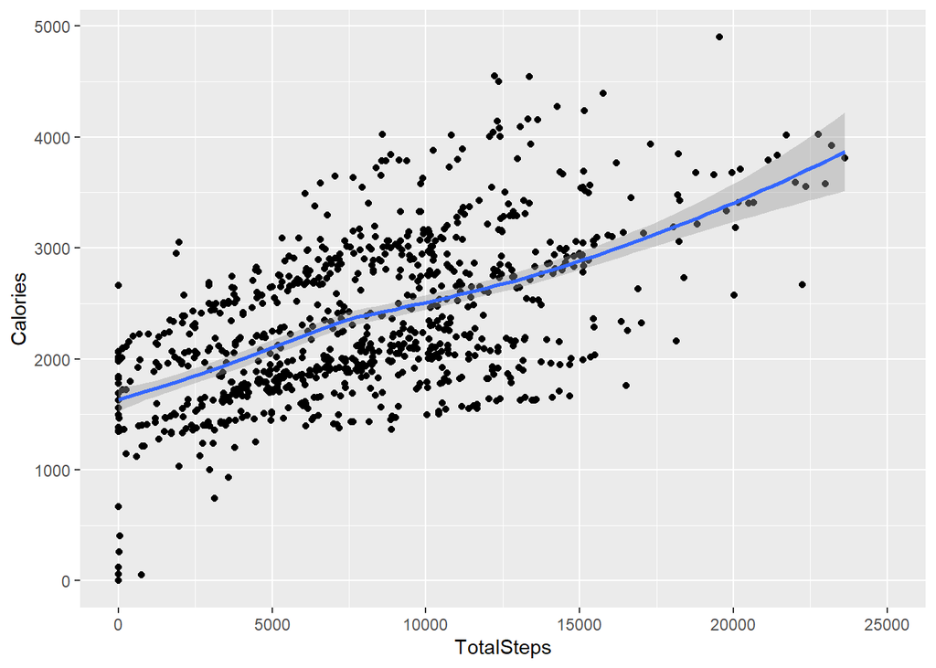

```r
ggplot(dailyActivity, aes(x = TotalSteps, y = Calories)) +
  geom_point() +
  xlim(0,25000) + # 3 obs > 25k skew the smoothed conf int
  geom_smooth()
```

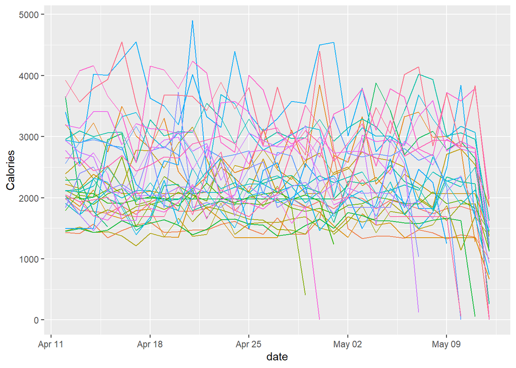

```r
ggplot(dailyCalories, aes(x = date, y = Calories, color = Id)) +
  geom_line(show.legend = FALSE)
```

Therefore, plotting only their daily average reveals a wide range.

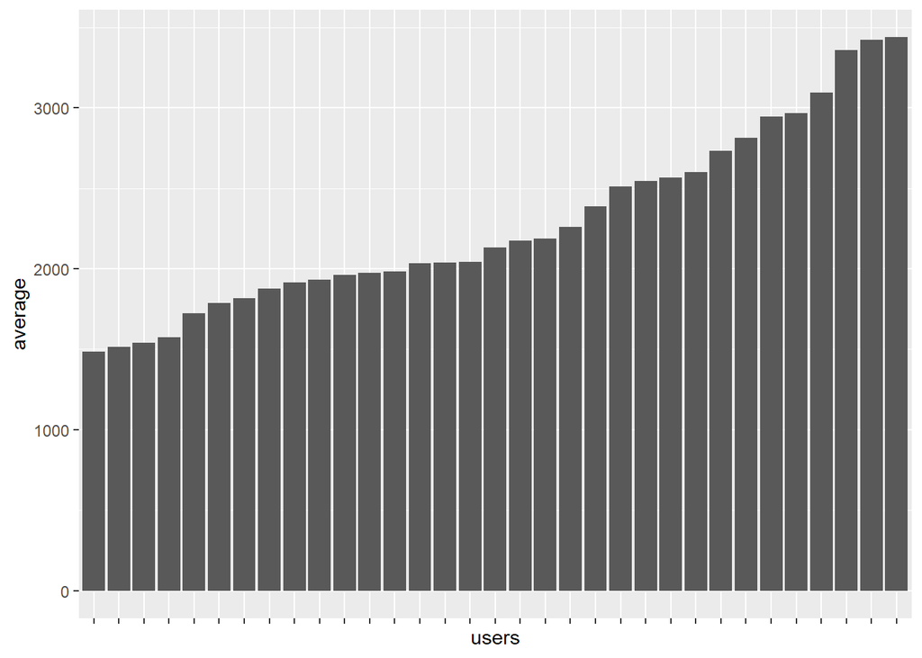

```r
ggplot(Calories, aes(x = reorder(Id, average), y = average)) +
  geom_col() +
  scale_x_discrete(name = "users", labels = NULL)
```

Likewise, plotting the steps revealed the same disparity.

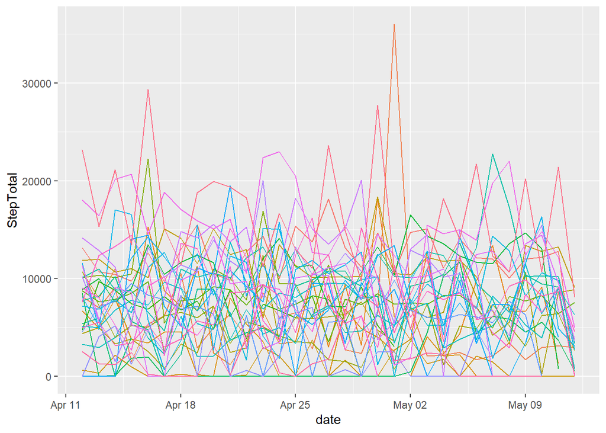

```r
ggplot(dailySteps, aes(x = date, y = StepTotal, color = Id)) +
  geom_line(show.legend = FALSE)
```

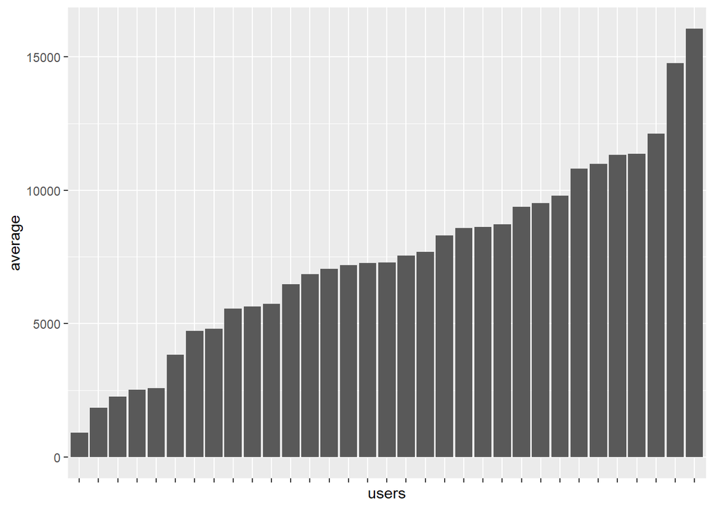

```r
ggplot(Steps, aes(x = reorder(Id, average), y = average)) +
  geom_col() +
  scale_x_discrete(name = "users", labels = NULL)
```

Turning to the intensity data, it is clear about half the participants wore their devices nearly 24 hours/day, while the rest probably wore them only during waking hours.

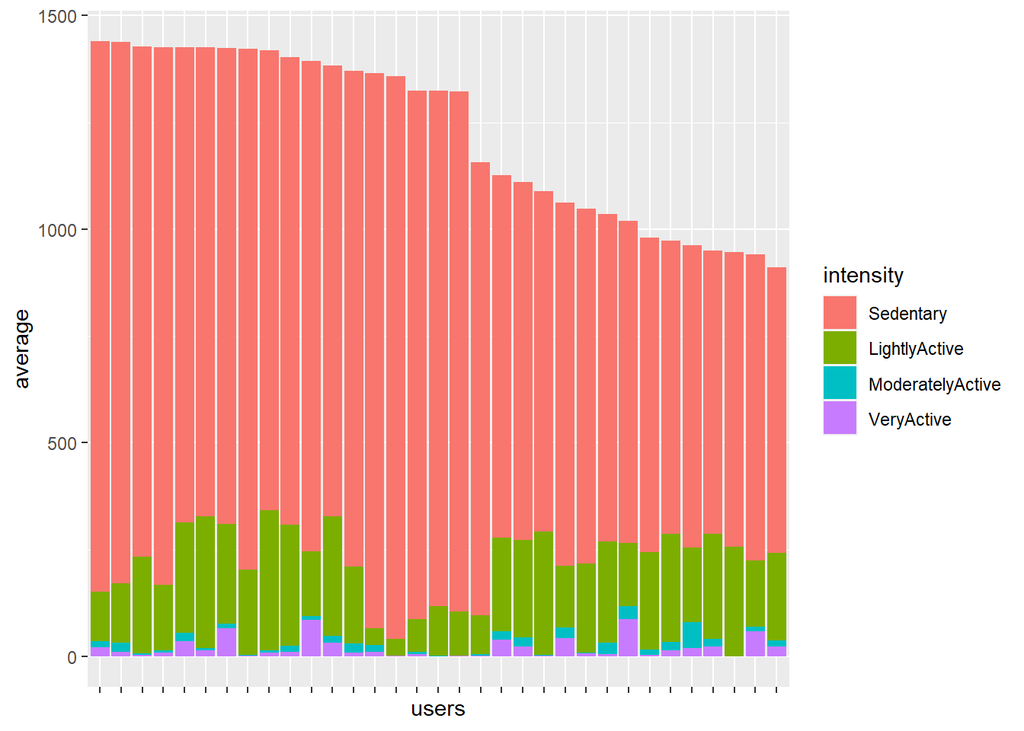

```r
ggplot(Intensity, aes(x = reorder(factor(Id), -average), y = average, fill = intensity)) +
  geom_col() +
  scale_x_discrete(name = "users", labels = NULL)
```

Filtering the intensity data for only non-sedentary activity is more helpful. Participants also ranged widely in activity, from more than five hours to less than one hour of average daily non-sedentary activity.

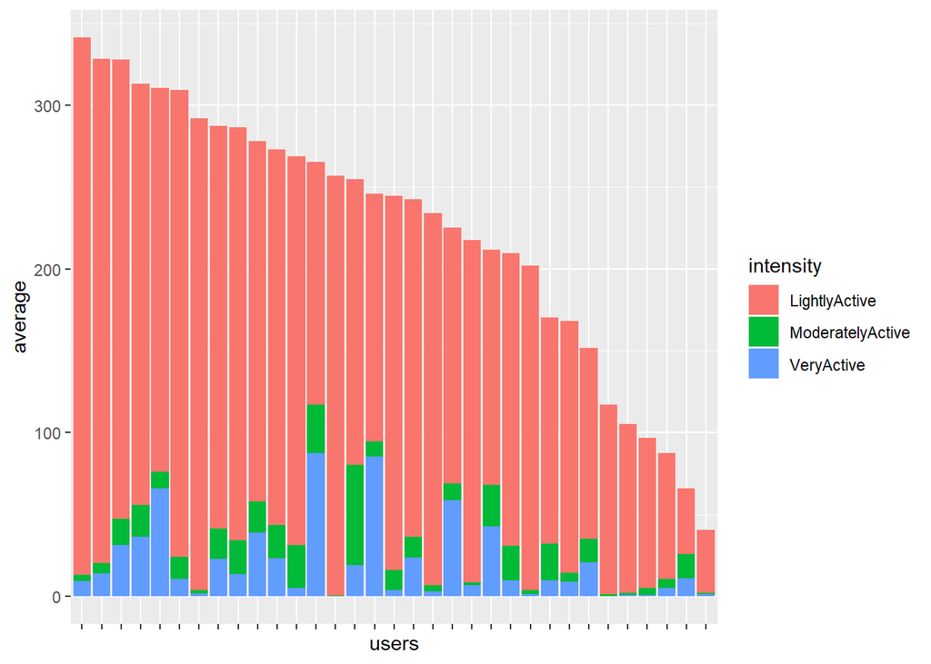

```r
ActiveIntensity <- Intensity %>%
  filter(intensity != "Sedentary")

ggplot(ActiveIntensity, aes(x = reorder(factor(Id), -average), y = average, fill = intensity)) +
  geom_col() +
  scale_x_discrete(name = "users", labels = NULL)
```

Going back to the summary activity data, adding the non-sedentary activity together and plotting that vs. calories shows a similarly obvious positive relationship between them, but with a slight plateau after about four hours or so.

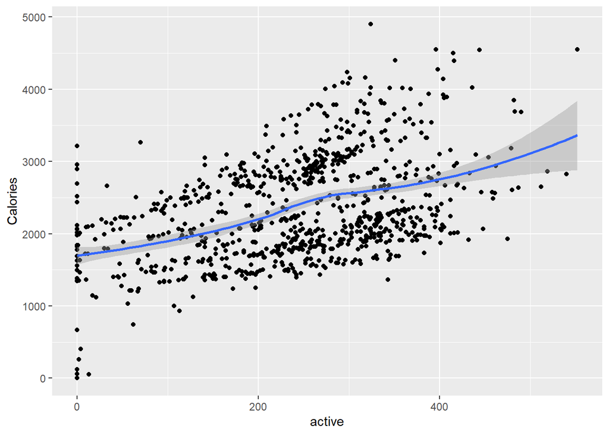

```r
dailyActivity <- dailyActivity %>%
  mutate(active = VeryActiveMinutes + FairlyActiveMinutes + LightlyActiveMinutes)

ggplot(dailyActivity, aes(x = active, y = Calories)) +
  geom_point() +
  geom_smooth()
```

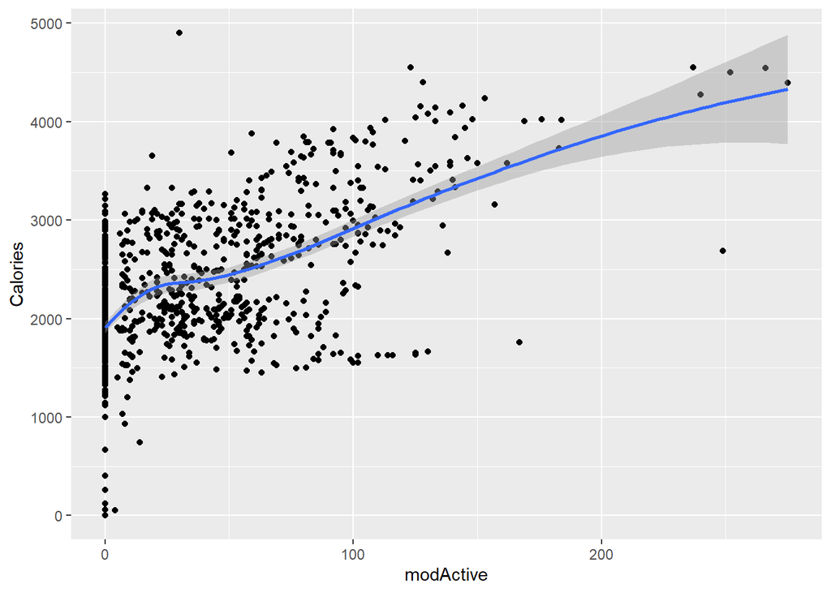

```r
dailyActivity <- dailyActivity %>%
  mutate(modActive = VeryActiveMinutes + FairlyActiveMinutes)

ggplot(dailyActivity, aes(x = modActive, y = Calories)) +
  geom_point() +
  geom_smooth()
```

```r
cor(dailyActivity$Calories, dailyActivity$active)
```

```
## [1] 0.4719975
```

```r
cor(dailyActivity$Calories, dailyActivity$modActive)
```

```
## [1] 0.6023439
```

Another issue in several of the previous graphs is that a large number of points with zero minutes still show a wide range of calories burned. These were possibly from days where the device was not used but calories were somehow still input. Filtering those points out and replotting the steps, active, and moderately active graphs shows the same general trends, but perhaps clearer. While the plateau around 15 minutes of moderate activity remains, after an hour or so, the positive correlation with calorie burn continues.

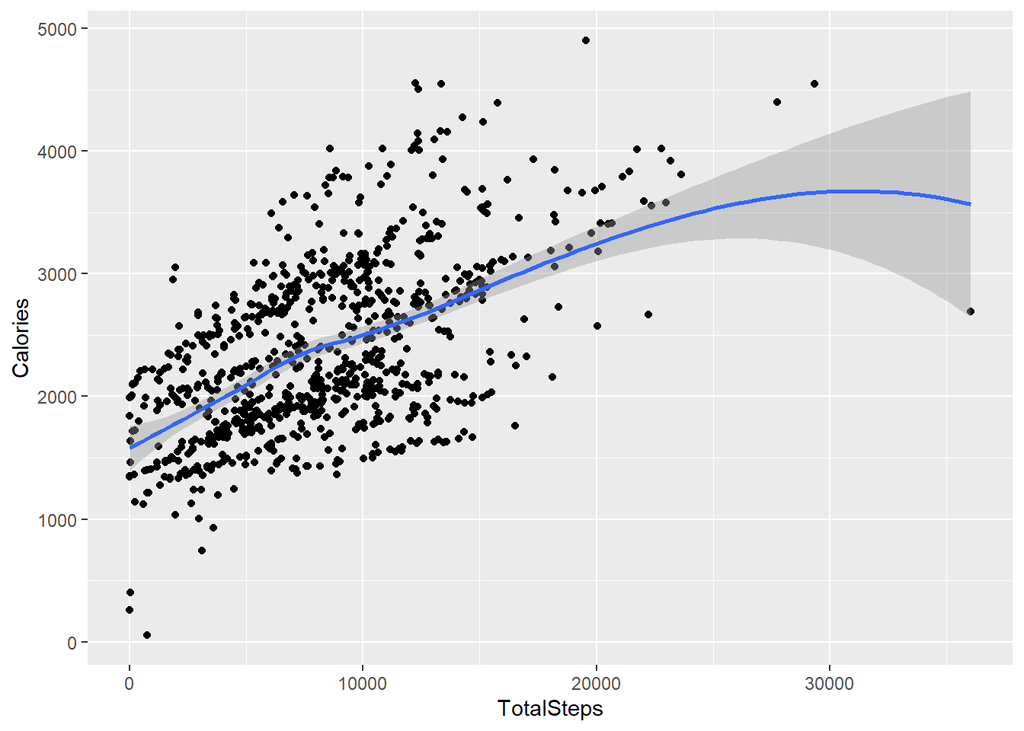

```r
dailyActivityNoZero <- dailyActivity %>%
  filter(TotalSteps > 0, active > 0)

ggplot(dailyActivityNoZero, aes(x = TotalSteps, y = Calories)) +
  geom_point() +
  geom_smooth()
```

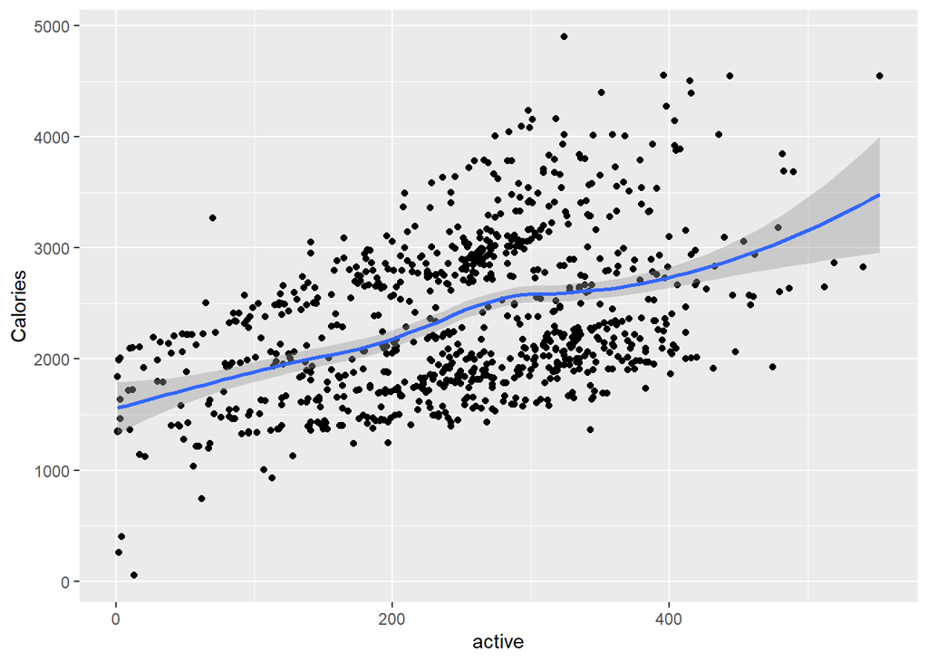

```r
ggplot(dailyActivityNoZero, aes(x = active, y = Calories)) +
  geom_point() +
  geom_smooth()
```

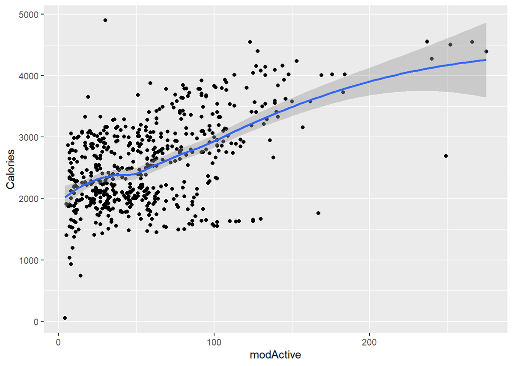

```r
dailyActivityNoModZero <- dailyActivityNoZero %>%
  filter(modActive > 0)

ggplot(dailyActivityNoModZero, aes(x = modActive, y = Calories)) +
  geom_point() +
  geom_smooth()
```

This analysis did not look at the sleep data.

## Key findings

- About half the participants in this dataset appeared to wear their smart devices all the time. The rest appeared to only wear them during waking hours. The latter may not be aware of devices’ ability to track sleep data.
- Although positive relationships between either total steps or non-sedentary activity are rather obvious, the activity data revealed plateaus in the relationship to calories burned.

## Recommendations

Marketing copy could emphasize the app/device features to track and analyze sleep patterns to ensure all users are aware of them.

Add features to the device/app that gently remind/nudge users to be more active, with goals to reach the active and/or moderately active plateaus. Furthermore, the device/app could be modified to identify these plateaus for individual users over time.

These features could be gamified, so reaching goals could generate points, which could be rewarded with “badges” for reaching milestones, e.g. so many consecutive or cumulative days of reaching specific goals, and competing among “friends” on the app. (See [Duolingo](https://www.duolingo.com/) for an example of a wildly successful app that does just that.)